# Module 129

#### Contrast SVE:

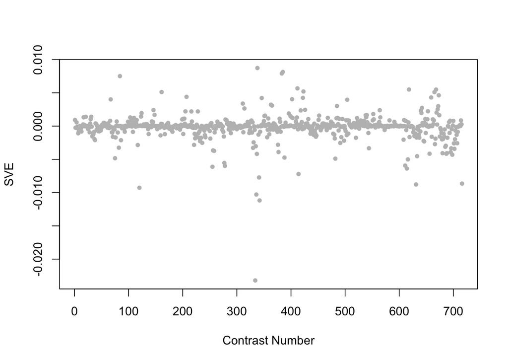

Positive SVE Contrasts:

|  | Contrast.Num | SVE | GEO.GSE | Cond.1 | Cond.2 | Mutation |
| --- | --- | --- | --- | --- | --- | --- |
| GSE38997.s2t1.vs.s1t1 | 338 | 0.01 | GSE38997 | experiment 4 EtBr-exposed samples at 3 h 4e3 | experiment 4 control samples at 3 h 4c3 |  |
| GSE34026.s3t1.vs.s0t1 | 385 | 0.01 | GSE34026 | N2 exposed to CVD110, biological rep1 | N2 exposed to OP50(E.coli), biological rep1 |  |
| GSE34113.s1t1.vs.s0t1 | 383 | 0.01 | GSE34113 | tdp-1(ok803) | wild-type 1 | tdp-1 |
| GSE6547.s2t2.vs.s0t2 | 84 | 0.01 | GSE6547 | slr-2(ku297) worms at L1 stage, first replicate | N2 (wt) worms at L1 stage, first replicate | sir-2 |
| GSE30505.s1t2.vs.s1t1 | 412 | 0.01 | GSE30505 | Day 8 N2 (WT) E.V. #1 | L3 N2 (WT) E.V. #1 |  |

Negative SVE Contrasts:

|  | Contrast.Num | SVE | GEO.GSE | Cond.1 | Cond.2 | Mutation |
| --- | --- | --- | --- | --- | --- | --- |
| GSE38997.s4t2.vs.s1t2 | 334 | -0.02 | GSE38997 | experiment 4 UVC-exposed samples at 24 h 4u24 | experiment 4 control samples at 24 h 4c24 |  |
| GSE38997.s4t1.vs.s2t1 | 342 | -0.01 | GSE38997 | experiment 4 UVC-exposed samples at 3 h 4u3 | experiment 4 EtBr-exposed samples at 3 h 4e3 |  |
| GSE38997.s4t2.vs.s2t2 | 336 | -0.01 | GSE38997 | experiment 4 UVC-exposed samples at 24 h 4u24 | experiment 4 EtBr-exposed samples at 24 h 4e24 |  |
| GSE54024.s3t1.vs.s4t1 | 120 | -0.01 | GSE54024 | nuo-6(qm200) young adults, biological rep 1 | isp-1(qm150) young adults, biological rep 1 |  |
| GSE19310B.s1t4.vs.s1t1 | 631 | -0.01 | GSE19310 | N2 at 200 for 1 generation, rep1 | N2 at 200 for 15min, rep1 |  |

$~$

#### Contrast SVE, Up-Regulated Genes Only:

Calculating SVE for up-regulated and down-regulated genes separately may be more informative in many cases than projecting the up- and down- gene sets together. This is due to the fact that the weight distribution of many modules is highly skewed, indicating that only one of the hemi-modules may be biologically meaningful (i.e., a set of genes are strongly correlated by only a few genes (or none) are strongly anti-correlated to that set.)

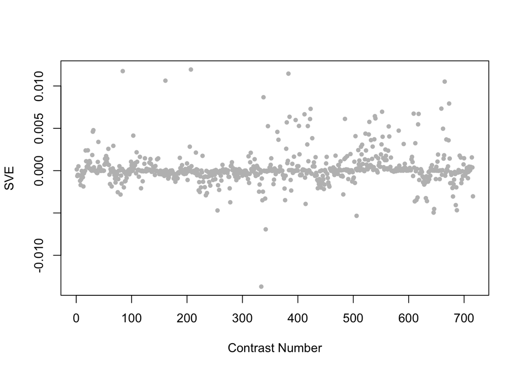

Positive SVE Contrasts:

|  | Contrast.Num | SVE | GEO.GSE | Cond.1 | Cond.2 | Mutation |
| --- | --- | --- | --- | --- | --- | --- |
| GSE42703.s1t2.vs.s1t1 | 207 | 0.01 | GSE42703 | kgb-1 incubated with H2O, biological rep1 | kgb-1 incubated with 1mM copper sulfate, biological rep1 |  |
| GSE6547.s2t2.vs.s0t2 | 84 | 0.01 | GSE6547 | slr-2(ku297) worms at L1 stage, first replicate | N2 (wt) worms at L1 stage, first replicate | sir-2 |
| GSE34113.s1t1.vs.s0t1 | 383 | 0.01 | GSE34113 | tdp-1(ok803) | wild-type 1 | tdp-1 |
| GSE47778.s4t2.vs.s3t2 | 161 | 0.01 | GSE47778 | daf-2;daf-16; starvation; replicate 1 | daf-16; starvation; replicate 1 | daf-2;daf-16 vs. daf-16 |
| GSE15159.s1t2.vs.s1t1 | 665 | 0.01 | GSE15159 | glp-1_UV_2007_rep1 | glp-1_control_2007_rep1 |  |

Negative SVE Contrasts:

|  | Contrast.Num | SVE | GEO.GSE | Cond.1 | Cond.2 | Mutation |
| --- | --- | --- | --- | --- | --- | --- |
| GSE38997.s4t2.vs.s1t2 | 334 | -0.01 | GSE38997 | experiment 4 UVC-exposed samples at 24 h 4u24 | experiment 4 control samples at 24 h 4c24 |  |
| GSE38997.s4t1.vs.s2t1 | 342 | -0.01 | GSE38997 | experiment 4 UVC-exposed samples at 3 h 4u3 | experiment 4 EtBr-exposed samples at 3 h 4e3 |  |
| GSE2210.s1t1.vs.s0t1 | 506 | -0.01 | GSE2210 | tom-1(nu468) Sample 1 | Wild type Sample 1 | tom-1 |
| GSE16915.s2t1.vs.s3t1 | 645 | -0.00 | GSE16915 | positive control (heat shock) | bio-electrosprayed sample |  |
| GSE41486.s2t1.vs.s1t1 | 255 | -0.00 | GSE41486 | C. elegans grown without a-SWCNT treatment for 48 hr at 22°C. | C. elegans exposed to 500 μg/mL of a-SWCNT for 48 hr at 22°C. |  |

$~$

#### Contrast SVE, Down-Regulated Genes Only:

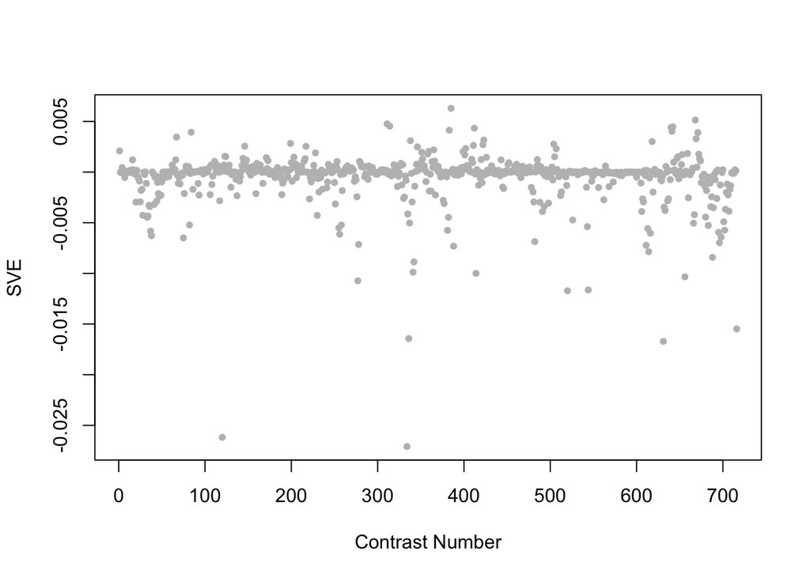

Positive SVE Contrasts:

|  | Contrast.Num | SVE | GEO.GSE | Cond.1 | Cond.2 | Mutation |
| --- | --- | --- | --- | --- | --- | --- |
| GSE34026.s3t1.vs.s0t1 | 385 | 0.01 | GSE34026 | N2 exposed to CVD110, biological rep1 | N2 exposed to OP50(E.coli), biological rep1 |  |
| GSE15016.s4t1.vs.s0t1 | 668 | 0.01 | GSE15016 | young adult_24hr BPA exposure_rep1 | young adult_not exposured_rep1 |  |
| GSE41056.s2t2.vs.s0t2 | 311 | 0.00 | GSE41056 | RDE_1_inf_1 | N2_inf_1 | rde-1 |
| GSE41056.s2t2.vs.s2t1 | 314 | 0.00 | GSE41056 | RDE_1_inf_1 | RDE_1_1 |  |
| GSE18132.s0t2.vs.s0t1 | 642 | 0.00 | GSE18132 | WT Fed L4, biological rep1 | WT Starved L1, biological rep1 |  |

Negative SVE Contrasts:

|  | Contrast.Num | SVE | GEO.GSE | Cond.1 | Cond.2 | Mutation |
| --- | --- | --- | --- | --- | --- | --- |
| GSE38997.s4t2.vs.s1t2 | 334 | -0.03 | GSE38997 | experiment 4 UVC-exposed samples at 24 h 4u24 | experiment 4 control samples at 24 h 4c24 |  |
| GSE54024.s3t1.vs.s4t1 | 120 | -0.03 | GSE54024 | nuo-6(qm200) young adults, biological rep 1 | isp-1(qm150) young adults, biological rep 1 |  |
| GSE19310B.s1t4.vs.s1t1 | 631 | -0.02 | GSE19310 | N2 at 200 for 1 generation, rep1 | N2 at 200 for 15min, rep1 |  |
| GSE38997.s4t2.vs.s2t2 | 336 | -0.02 | GSE38997 | experiment 4 UVC-exposed samples at 24 h 4u24 | experiment 4 EtBr-exposed samples at 24 h 4e24 |  |
| GSE10787B.s1t1.vs.s0t1 | 716 | -0.02 | GSE10787 | Microwave (de_Pomerai_10_E5_C.Elegans) | Sham (de_Pomerai_1_S1_C.Elegans) |  |

$~$

$~$

#### GO Term Enrichment:

This analysis tests each hemi-module for enrichment of specific GO terms. Only gene-level annotations (e.g., as would be found on the gene’s page in Wormbase) are tested - the hierarchical structure of the GO ontology is not taken into account.

*Note: At least the top two most enriched terms from each GO domain (BP/MF/CC) are shown, even when not statistically significant.*

##### Enriched GO terms: Hemi-module A

| ID | GO.Term | GO Domain | Raw p-value | Adj p-value |
| --- | --- | --- | --- | --- |
| [GO_0007010](http://amigo.geneontology.org/amigo/term/GO:0007010) | cytoskeleton organization | BP | 2.42e-04 | 8.83e-01 |
| [GO_0006997](http://amigo.geneontology.org/amigo/term/GO:0006997) | nucleus organization | BP | 2.51e-03 | 9.88e-01 |
| [GO_0017112](http://amigo.geneontology.org/amigo/term/GO:0017112) | Rab guanyl-nucleotide exchange factor activity | MF | 7.16e-03 | 9.91e-01 |
| [GO_0005267](http://amigo.geneontology.org/amigo/term/GO:0005267) | potassium channel activity | MF | 1.21e-02 | 9.91e-01 |
| [GO_0005881](http://amigo.geneontology.org/amigo/term/GO:0005881) | cytoplasmic microtubule | CC | 3.07e-03 | 9.90e-01 |
| [GO_0000235](http://amigo.geneontology.org/amigo/term/GO:0000235) | astral microtubule | CC | 4.26e-03 | 9.90e-01 |

##### Enriched GO terms: Hemi-module B

| ID | GO.Term | GO Domain | Raw p-value | Adj p-value |
| --- | --- | --- | --- | --- |
| [GO_0042059](http://amigo.geneontology.org/amigo/term/GO:0042059) | negative regulation of epidermal growth factor receptor signaling pathway | BP | 1.11e-03 | 9.94e-01 |
| [GO_0072327](http://amigo.geneontology.org/amigo/term/GO:0072327) | vulval cell fate specification | BP | 2.61e-03 | 9.94e-01 |
| [GO_0008234](http://amigo.geneontology.org/amigo/term/GO:0008234) | cysteine-type peptidase activity | MF | 2.46e-03 | 9.97e-01 |
| [GO_0004176](http://amigo.geneontology.org/amigo/term/GO:0004176) | ATP-dependent peptidase activity | MF | 3.94e-03 | 9.97e-01 |
| [GO_0001726](http://amigo.geneontology.org/amigo/term/GO:0001726) | ruffle | CC | 4.47e-04 | 4.15e-01 |
| [GO_0009368](http://amigo.geneontology.org/amigo/term/GO:0009368) | endopeptidase Clp complex | CC | 8.73e-03 | 9.96e-01 |

$~$

$~$

#### Tissue Enrichment:

This analysis tests each hemi-module for enrichment of genes associated with anatomy terms. Negative enrichment scores indicate fewer hemi-module genes than expected by random chance were associated with the anatomy term in question.

##### Enriched tissues: Hemi-module A

No significant annotations.

##### Enriched tissues: Hemi-module B

No significant annotations.

$~$

$~$

#### HOMER promoter motif enrichment:

This analysis tests each hemi-module for enrichment of 108 known *C. elegans* transcription factor binding site motifs (see [108 CE motifs](https://katiepod.github.io//all.worm.motifs.html)) using the HOMER (Hypergeometric Optimization of Motif EnRichment) software (see [PMID:20513432](https://pubmed.ncbi.nlm.nih.gov/20513432)). HOMER was run using default parameters on sequences 1 kb upstream of the transcription start site.

##### Motif enrichment: Hemi-module A

Total target sequences = 265  
Total background sequences = 39732  
* - possible false positive

Rank

Motif

P-value

log P-pvalue

% of Targets

% of Background

STD(Bg STD)

Best Match/Details

Motif File

1 *

[figure not shown]

1e-11

-2.612e+01

3.77%

0.12%

246.9bp (260.5bp)

pal-1/MA0924.1/Jaspar(0.595)  
[More Information](https://katiepod.github.io/HomerResults/m129_a_hemi_genes.txt.out.1kb/homerResults/motif1.info.html) | [Similar Motifs Found](https://katiepod.github.io/HomerResults/m129_a_hemi_genes.txt.out.1kb/homerResults/motif1.similar.html)

[motif file (matrix)](https://katiepod.github.io/HomerResults/m129_a_hemi_genes.txt.out.1kb/homerResults/motif1.motif)

2 *

[figure not shown]

1e-10

-2.490e+01

4.53%

0.26%

251.9bp (287.3bp)

SD0001.1_at_AC_acceptor/Jaspar(0.541)  
[More Information](https://katiepod.github.io/HomerResults/m129_a_hemi_genes.txt.out.1kb/homerResults/motif2.info.html) | [Similar Motifs Found](https://katiepod.github.io/HomerResults/m129_a_hemi_genes.txt.out.1kb/homerResults/motif2.similar.html)

[motif file (matrix)](https://katiepod.github.io/HomerResults/m129_a_hemi_genes.txt.out.1kb/homerResults/motif2.motif)

3 *

[figure not shown]

1e-10

-2.404e+01

6.04%

0.63%

329.1bp (263.8bp)

SD0003.1_at_AC_acceptor/Jaspar(0.635)  
[More Information](https://katiepod.github.io/HomerResults/m129_a_hemi_genes.txt.out.1kb/homerResults/motif3.info.html) | [Similar Motifs Found](https://katiepod.github.io/HomerResults/m129_a_hemi_genes.txt.out.1kb/homerResults/motif3.similar.html)

[motif file (matrix)](https://katiepod.github.io/HomerResults/m129_a_hemi_genes.txt.out.1kb/homerResults/motif3.motif)

4 *

[figure not shown]

1e-10

-2.397e+01

7.17%

0.97%

302.8bp (320.3bp)

DPL-1(E2F)/cElegans-Adult-ChIP-Seq(modEncode)/Homer(0.630)  
[More Information](https://katiepod.github.io/HomerResults/m129_a_hemi_genes.txt.out.1kb/homerResults/motif4.info.html) | [Similar Motifs Found](https://katiepod.github.io/HomerResults/m129_a_hemi_genes.txt.out.1kb/homerResults/motif4.similar.html)

[motif file (matrix)](https://katiepod.github.io/HomerResults/m129_a_hemi_genes.txt.out.1kb/homerResults/motif4.motif)

5 *

[figure not shown]

1e-10

-2.310e+01

5.66%

0.57%

283.1bp (339.5bp)

ceh-28/MA1445.1/Jaspar(0.758)  
[More Information](https://katiepod.github.io/HomerResults/m129_a_hemi_genes.txt.out.1kb/homerResults/motif5.info.html) | [Similar Motifs Found](https://katiepod.github.io/HomerResults/m129_a_hemi_genes.txt.out.1kb/homerResults/motif5.similar.html)

[motif file (matrix)](https://katiepod.github.io/HomerResults/m129_a_hemi_genes.txt.out.1kb/homerResults/motif5.motif)

6 *

[figure not shown]

1e-9

-2.279e+01

4.15%

0.24%

307.3bp (265.5bp)

elt-2/MA1701.1/Jaspar(0.837)  
[More Information](https://katiepod.github.io/HomerResults/m129_a_hemi_genes.txt.out.1kb/homerResults/motif6.info.html) | [Similar Motifs Found](https://katiepod.github.io/HomerResults/m129_a_hemi_genes.txt.out.1kb/homerResults/motif6.similar.html)

[motif file (matrix)](https://katiepod.github.io/HomerResults/m129_a_hemi_genes.txt.out.1kb/homerResults/motif6.motif)

7 *

[figure not shown]

1e-9

-2.263e+01

20.75%

8.15%

261.0bp (308.7bp)

mab-3/MA0262.1/Jaspar(0.562)  
[More Information](https://katiepod.github.io/HomerResults/m129_a_hemi_genes.txt.out.1kb/homerResults/motif7.info.html) | [Similar Motifs Found](https://katiepod.github.io/HomerResults/m129_a_hemi_genes.txt.out.1kb/homerResults/motif7.similar.html)

[motif file (matrix)](https://katiepod.github.io/HomerResults/m129_a_hemi_genes.txt.out.1kb/homerResults/motif7.motif)

8 *

[figure not shown]

1e-9

-2.184e+01

3.02%

0.09%

263.0bp (303.1bp)

unc-30/MA1443.1/Jaspar(0.523)  
[More Information](https://katiepod.github.io/HomerResults/m129_a_hemi_genes.txt.out.1kb/homerResults/motif8.info.html) | [Similar Motifs Found](https://katiepod.github.io/HomerResults/m129_a_hemi_genes.txt.out.1kb/homerResults/motif8.similar.html)

[motif file (matrix)](https://katiepod.github.io/HomerResults/m129_a_hemi_genes.txt.out.1kb/homerResults/motif8.motif)

9 *

[figure not shown]

1e-9

-2.133e+01

2.64%

0.05%

247.0bp (351.6bp)

sma-4/MA0925.1/Jaspar(0.576)  
[More Information](https://katiepod.github.io/HomerResults/m129_a_hemi_genes.txt.out.1kb/homerResults/motif9.info.html) | [Similar Motifs Found](https://katiepod.github.io/HomerResults/m129_a_hemi_genes.txt.out.1kb/homerResults/motif9.similar.html)

[motif file (matrix)](https://katiepod.github.io/HomerResults/m129_a_hemi_genes.txt.out.1kb/homerResults/motif9.motif)

10 *

[figure not shown]

1e-8

-2.055e+01

2.64%

0.06%

136.5bp (311.5bp)

MF0006.1_bZIP_cEBP-like_subclass/Jaspar(0.662)  
[More Information](https://katiepod.github.io/HomerResults/m129_a_hemi_genes.txt.out.1kb/homerResults/motif10.info.html) | [Similar Motifs Found](https://katiepod.github.io/HomerResults/m129_a_hemi_genes.txt.out.1kb/homerResults/motif10.similar.html)

[motif file (matrix)](https://katiepod.github.io/HomerResults/m129_a_hemi_genes.txt.out.1kb/homerResults/motif10.motif)

11 *

[figure not shown]

1e-8

-2.022e+01

5.28%

0.60%

295.1bp (294.5bp)

SD0003.1_at_AC_acceptor/Jaspar(0.545)  
[More Information](https://katiepod.github.io/HomerResults/m129_a_hemi_genes.txt.out.1kb/homerResults/motif11.info.html) | [Similar Motifs Found](https://katiepod.github.io/HomerResults/m129_a_hemi_genes.txt.out.1kb/homerResults/motif11.similar.html)

[motif file (matrix)](https://katiepod.github.io/HomerResults/m129_a_hemi_genes.txt.out.1kb/homerResults/motif11.motif)

12 *

[figure not shown]

1e-8

-2.009e+01

6.79%

1.10%

257.2bp (316.4bp)

ceh-38/MA1699.1/Jaspar(0.654)  
[More Information](https://katiepod.github.io/HomerResults/m129_a_hemi_genes.txt.out.1kb/homerResults/motif12.info.html) | [Similar Motifs Found](https://katiepod.github.io/HomerResults/m129_a_hemi_genes.txt.out.1kb/homerResults/motif12.similar.html)

[motif file (matrix)](https://katiepod.github.io/HomerResults/m129_a_hemi_genes.txt.out.1kb/homerResults/motif12.motif)

13 *

[figure not shown]

1e-8

-1.993e+01

8.30%

1.71%

256.9bp (299.2bp)

MF0004.1_Nuclear_Receptor_class/Jaspar(0.668)  
[More Information](https://katiepod.github.io/HomerResults/m129_a_hemi_genes.txt.out.1kb/homerResults/motif13.info.html) | [Similar Motifs Found](https://katiepod.github.io/HomerResults/m129_a_hemi_genes.txt.out.1kb/homerResults/motif13.similar.html)

[motif file (matrix)](https://katiepod.github.io/HomerResults/m129_a_hemi_genes.txt.out.1kb/homerResults/motif13.motif)

14 *

[figure not shown]

1e-8

-1.962e+01

1.89%

0.01%

260.1bp (315.1bp)

fos-1/MA1448.1/Jaspar(0.481)  
[More Information](https://katiepod.github.io/HomerResults/m129_a_hemi_genes.txt.out.1kb/homerResults/motif14.info.html) | [Similar Motifs Found](https://katiepod.github.io/HomerResults/m129_a_hemi_genes.txt.out.1kb/homerResults/motif14.similar.html)

[motif file (matrix)](https://katiepod.github.io/HomerResults/m129_a_hemi_genes.txt.out.1kb/homerResults/motif14.motif)

15 *

[figure not shown]

1e-8

-1.909e+01

6.79%

1.17%

264.7bp (320.9bp)

MF0002.1_bZIP_CREB/G-box-like_subclass/Jaspar(0.612)  
[More Information](https://katiepod.github.io/HomerResults/m129_a_hemi_genes.txt.out.1kb/homerResults/motif15.info.html) | [Similar Motifs Found](https://katiepod.github.io/HomerResults/m129_a_hemi_genes.txt.out.1kb/homerResults/motif15.similar.html)

[motif file (matrix)](https://katiepod.github.io/HomerResults/m129_a_hemi_genes.txt.out.1kb/homerResults/motif15.motif)

16 *

[figure not shown]

1e-8

-1.893e+01

4.91%

0.55%

300.4bp (312.0bp)

skn-1/MA0547.1/Jaspar(0.588)  
[More Information](https://katiepod.github.io/HomerResults/m129_a_hemi_genes.txt.out.1kb/homerResults/motif16.info.html) | [Similar Motifs Found](https://katiepod.github.io/HomerResults/m129_a_hemi_genes.txt.out.1kb/homerResults/motif16.similar.html)

[motif file (matrix)](https://katiepod.github.io/HomerResults/m129_a_hemi_genes.txt.out.1kb/homerResults/motif16.motif)

17 *

[figure not shown]

1e-8

-1.847e+01

11.32%

3.34%

323.7bp (295.5bp)

ceh-22/MA0264.1/Jaspar(0.534)  
[More Information](https://katiepod.github.io/HomerResults/m129_a_hemi_genes.txt.out.1kb/homerResults/motif17.info.html) | [Similar Motifs Found](https://katiepod.github.io/HomerResults/m129_a_hemi_genes.txt.out.1kb/homerResults/motif17.similar.html)

[motif file (matrix)](https://katiepod.github.io/HomerResults/m129_a_hemi_genes.txt.out.1kb/homerResults/motif17.motif)

18 *

[figure not shown]

1e-7

-1.732e+01

7.55%

1.64%

295.7bp (303.1bp)

PL0001.1_hlh-11/Jaspar(0.672)  
[More Information](https://katiepod.github.io/HomerResults/m129_a_hemi_genes.txt.out.1kb/homerResults/motif18.info.html) | [Similar Motifs Found](https://katiepod.github.io/HomerResults/m129_a_hemi_genes.txt.out.1kb/homerResults/motif18.similar.html)

[motif file (matrix)](https://katiepod.github.io/HomerResults/m129_a_hemi_genes.txt.out.1kb/homerResults/motif18.motif)

19 *

[figure not shown]

1e-7

-1.713e+01

4.53%

0.53%

290.2bp (315.7bp)

pha-4/MA0546.1/Jaspar(0.543)  
[More Information](https://katiepod.github.io/HomerResults/m129_a_hemi_genes.txt.out.1kb/homerResults/motif19.info.html) | [Similar Motifs Found](https://katiepod.github.io/HomerResults/m129_a_hemi_genes.txt.out.1kb/homerResults/motif19.similar.html)

[motif file (matrix)](https://katiepod.github.io/HomerResults/m129_a_hemi_genes.txt.out.1kb/homerResults/motif19.motif)

20 *

[figure not shown]

1e-7

-1.702e+01

9.43%

2.57%

286.4bp (314.5bp)

fkh-9/MA1440.1/Jaspar(0.624)  
[More Information](https://katiepod.github.io/HomerResults/m129_a_hemi_genes.txt.out.1kb/homerResults/motif20.info.html) | [Similar Motifs Found](https://katiepod.github.io/HomerResults/m129_a_hemi_genes.txt.out.1kb/homerResults/motif20.similar.html)

[motif file (matrix)](https://katiepod.github.io/HomerResults/m129_a_hemi_genes.txt.out.1kb/homerResults/motif20.motif)

21 *

[figure not shown]

1e-6

-1.564e+01

11.70%

4.03%

240.1bp (302.9bp)

zfh-2/MA0928.1/Jaspar(0.624)  
[More Information](https://katiepod.github.io/HomerResults/m129_a_hemi_genes.txt.out.1kb/homerResults/motif21.info.html) | [Similar Motifs Found](https://katiepod.github.io/HomerResults/m129_a_hemi_genes.txt.out.1kb/homerResults/motif21.similar.html)

[motif file (matrix)](https://katiepod.github.io/HomerResults/m129_a_hemi_genes.txt.out.1kb/homerResults/motif21.motif)

22 *

[figure not shown]

1e-6

-1.512e+01

13.96%

5.51%

282.3bp (303.3bp)

MF0001.1_ETS_class/Jaspar(0.678)  
[More Information](https://katiepod.github.io/HomerResults/m129_a_hemi_genes.txt.out.1kb/homerResults/motif22.info.html) | [Similar Motifs Found](https://katiepod.github.io/HomerResults/m129_a_hemi_genes.txt.out.1kb/homerResults/motif22.similar.html)

[motif file (matrix)](https://katiepod.github.io/HomerResults/m129_a_hemi_genes.txt.out.1kb/homerResults/motif22.motif)

23 *

[figure not shown]

1e-6

-1.477e+01

1.51%

0.02%

206.9bp (267.8bp)

POL008.1_DCE_S_I/Jaspar(0.555)  
[More Information](https://katiepod.github.io/HomerResults/m129_a_hemi_genes.txt.out.1kb/homerResults/motif23.info.html) | [Similar Motifs Found](https://katiepod.github.io/HomerResults/m129_a_hemi_genes.txt.out.1kb/homerResults/motif23.similar.html)

[motif file (matrix)](https://katiepod.github.io/HomerResults/m129_a_hemi_genes.txt.out.1kb/homerResults/motif23.motif)

24 *

[figure not shown]

1e-6

-1.475e+01

3.40%

0.33%

228.1bp (289.8bp)

PL0012.1_hlh-2::hlh-8/Jaspar(0.564)  
[More Information](https://katiepod.github.io/HomerResults/m129_a_hemi_genes.txt.out.1kb/homerResults/motif24.info.html) | [Similar Motifs Found](https://katiepod.github.io/HomerResults/m129_a_hemi_genes.txt.out.1kb/homerResults/motif24.similar.html)

[motif file (matrix)](https://katiepod.github.io/HomerResults/m129_a_hemi_genes.txt.out.1kb/homerResults/motif24.motif)

25 *

[figure not shown]

1e-6

-1.418e+01

8.30%

2.39%

283.7bp (304.5bp)

POL002.1_INR/Jaspar(0.595)  
[More Information](https://katiepod.github.io/HomerResults/m129_a_hemi_genes.txt.out.1kb/homerResults/motif25.info.html) | [Similar Motifs Found](https://katiepod.github.io/HomerResults/m129_a_hemi_genes.txt.out.1kb/homerResults/motif25.similar.html)

[motif file (matrix)](https://katiepod.github.io/HomerResults/m129_a_hemi_genes.txt.out.1kb/homerResults/motif25.motif)

26 *

[figure not shown]

1e-5

-1.277e+01

1.13%

0.01%

66.5bp (272.3bp)

POL004.1_CCAAT-box/Jaspar(0.508)  
[More Information](https://katiepod.github.io/HomerResults/m129_a_hemi_genes.txt.out.1kb/homerResults/motif26.info.html) | [Similar Motifs Found](https://katiepod.github.io/HomerResults/m129_a_hemi_genes.txt.out.1kb/homerResults/motif26.similar.html)

[motif file (matrix)](https://katiepod.github.io/HomerResults/m129_a_hemi_genes.txt.out.1kb/homerResults/motif26.motif)

27 *

[figure not shown]

1e-4

-1.070e+01

5.28%

1.36%

296.5bp (302.0bp)

POL004.1_CCAAT-box/Jaspar(0.551)  
[More Information](https://katiepod.github.io/HomerResults/m129_a_hemi_genes.txt.out.1kb/homerResults/motif27.info.html) | [Similar Motifs Found](https://katiepod.github.io/HomerResults/m129_a_hemi_genes.txt.out.1kb/homerResults/motif27.similar.html)

[motif file (matrix)](https://katiepod.github.io/HomerResults/m129_a_hemi_genes.txt.out.1kb/homerResults/motif27.motif)

28 *

[figure not shown]

1e-4

-1.070e+01

16.98%

8.89%

263.6bp (298.6bp)

POL012.1_TATA-Box/Jaspar(0.681)  
[More Information](https://katiepod.github.io/HomerResults/m129_a_hemi_genes.txt.out.1kb/homerResults/motif28.info.html) | [Similar Motifs Found](https://katiepod.github.io/HomerResults/m129_a_hemi_genes.txt.out.1kb/homerResults/motif28.similar.html)

[motif file (matrix)](https://katiepod.github.io/HomerResults/m129_a_hemi_genes.txt.out.1kb/homerResults/motif28.motif)

29 *

[figure not shown]

1e-4

-9.762e+00

2.64%

0.35%

262.4bp (276.1bp)

MF0009.1_TRP(MYB)_class/Jaspar(0.545)  
[More Information](https://katiepod.github.io/HomerResults/m129_a_hemi_genes.txt.out.1kb/homerResults/motif29.info.html) | [Similar Motifs Found](https://katiepod.github.io/HomerResults/m129_a_hemi_genes.txt.out.1kb/homerResults/motif29.similar.html)

[motif file (matrix)](https://katiepod.github.io/HomerResults/m129_a_hemi_genes.txt.out.1kb/homerResults/motif29.motif)

30 *

[figure not shown]

1e-4

-9.345e+00

2.64%

0.38%

317.4bp (297.7bp)

PL0001.1_hlh-11/Jaspar(0.587)  
[More Information](https://katiepod.github.io/HomerResults/m129_a_hemi_genes.txt.out.1kb/homerResults/motif30.info.html) | [Similar Motifs Found](https://katiepod.github.io/HomerResults/m129_a_hemi_genes.txt.out.1kb/homerResults/motif30.similar.html)

[motif file (matrix)](https://katiepod.github.io/HomerResults/m129_a_hemi_genes.txt.out.1kb/homerResults/motif30.motif)

31 *

[figure not shown]

1e-3

-9.083e+00

4.15%

1.02%

221.1bp (345.3bp)

ceh-38/MA1699.1/Jaspar(0.774)  
[More Information](https://katiepod.github.io/HomerResults/m129_a_hemi_genes.txt.out.1kb/homerResults/motif31.info.html) | [Similar Motifs Found](https://katiepod.github.io/HomerResults/m129_a_hemi_genes.txt.out.1kb/homerResults/motif31.similar.html)

[motif file (matrix)](https://katiepod.github.io/HomerResults/m129_a_hemi_genes.txt.out.1kb/homerResults/motif31.motif)

32 *

[figure not shown]

1e-3

-7.910e+00

3.77%

0.98%

247.2bp (300.0bp)

POL009.1_DCE_S_II/Jaspar(0.495)  
[More Information](https://katiepod.github.io/HomerResults/m129_a_hemi_genes.txt.out.1kb/homerResults/motif32.info.html) | [Similar Motifs Found](https://katiepod.github.io/HomerResults/m129_a_hemi_genes.txt.out.1kb/homerResults/motif32.similar.html)

[motif file (matrix)](https://katiepod.github.io/HomerResults/m129_a_hemi_genes.txt.out.1kb/homerResults/motif32.motif)

33 *

[figure not shown]

1e-3

-7.346e+00

0.75%

0.01%

56.9bp (75.1bp)

POL001.1_MTE/Jaspar(0.529)  
[More Information](https://katiepod.github.io/HomerResults/m129_a_hemi_genes.txt.out.1kb/homerResults/motif33.info.html) | [Similar Motifs Found](https://katiepod.github.io/HomerResults/m129_a_hemi_genes.txt.out.1kb/homerResults/motif33.similar.html)

[motif file (matrix)](https://katiepod.github.io/HomerResults/m129_a_hemi_genes.txt.out.1kb/homerResults/motif33.motif)

34 *

[figure not shown]

1e-3

-7.014e+00

0.75%

0.01%

61.0bp (194.7bp)

unc-62/MA0918.1/Jaspar(0.611)  
[More Information](https://katiepod.github.io/HomerResults/m129_a_hemi_genes.txt.out.1kb/homerResults/motif34.info.html) | [Similar Motifs Found](https://katiepod.github.io/HomerResults/m129_a_hemi_genes.txt.out.1kb/homerResults/motif34.similar.html)

[motif file (matrix)](https://katiepod.github.io/HomerResults/m129_a_hemi_genes.txt.out.1kb/homerResults/motif34.motif)

##### Motif enrichment: Hemi-module B

Total target sequences = 135  
Total background sequences = 40389  
* - possible false positive

Rank

Motif

P-value

log P-pvalue

% of Targets

% of Background

STD(Bg STD)

Best Match/Details

Motif File

1 *

[figure not shown]

1e-11

-2.562e+01

6.67%

0.18%

251.6bp (272.3bp)

fos-1/MA1448.1/Jaspar(0.621)  
[More Information](https://katiepod.github.io/HomerResults/m129_b_hemi_genes.txt.out.1kb/homerResults/motif1.info.html) | [Similar Motifs Found](https://katiepod.github.io/HomerResults/m129_b_hemi_genes.txt.out.1kb/homerResults/motif1.similar.html)

[motif file (matrix)](https://katiepod.github.io/HomerResults/m129_b_hemi_genes.txt.out.1kb/homerResults/motif1.motif)

2 *

[figure not shown]

1e-10

-2.354e+01

4.44%

0.04%

158.7bp (352.1bp)

SD0001.1_at_AC_acceptor/Jaspar(0.632)  
[More Information](https://katiepod.github.io/HomerResults/m129_b_hemi_genes.txt.out.1kb/homerResults/motif2.info.html) | [Similar Motifs Found](https://katiepod.github.io/HomerResults/m129_b_hemi_genes.txt.out.1kb/homerResults/motif2.similar.html)

[motif file (matrix)](https://katiepod.github.io/HomerResults/m129_b_hemi_genes.txt.out.1kb/homerResults/motif2.motif)

3 *

[figure not shown]

1e-10

-2.318e+01

7.41%

0.34%

253.0bp (330.2bp)

pqm-1/MA1703.1/Jaspar(0.588)  
[More Information](https://katiepod.github.io/HomerResults/m129_b_hemi_genes.txt.out.1kb/homerResults/motif3.info.html) | [Similar Motifs Found](https://katiepod.github.io/HomerResults/m129_b_hemi_genes.txt.out.1kb/homerResults/motif3.similar.html)

[motif file (matrix)](https://katiepod.github.io/HomerResults/m129_b_hemi_genes.txt.out.1kb/homerResults/motif3.motif)

4 *

[figure not shown]

1e-9

-2.275e+01

14.07%

2.14%

273.8bp (309.8bp)

fkh-9/MA1440.1/Jaspar(0.694)  
[More Information](https://katiepod.github.io/HomerResults/m129_b_hemi_genes.txt.out.1kb/homerResults/motif4.info.html) | [Similar Motifs Found](https://katiepod.github.io/HomerResults/m129_b_hemi_genes.txt.out.1kb/homerResults/motif4.similar.html)

[motif file (matrix)](https://katiepod.github.io/HomerResults/m129_b_hemi_genes.txt.out.1kb/homerResults/motif4.motif)

5 *

[figure not shown]

1e-9

-2.250e+01

6.67%

0.26%

217.0bp (286.0bp)

MF0004.1_Nuclear_Receptor_class/Jaspar(0.590)  
[More Information](https://katiepod.github.io/HomerResults/m129_b_hemi_genes.txt.out.1kb/homerResults/motif5.info.html) | [Similar Motifs Found](https://katiepod.github.io/HomerResults/m129_b_hemi_genes.txt.out.1kb/homerResults/motif5.similar.html)

[motif file (matrix)](https://katiepod.github.io/HomerResults/m129_b_hemi_genes.txt.out.1kb/homerResults/motif5.motif)

6 *

[figure not shown]

1e-9

-2.231e+01

8.89%

0.67%

357.8bp (301.1bp)

ces-2/MA0922.1/Jaspar(0.644)  
[More Information](https://katiepod.github.io/HomerResults/m129_b_hemi_genes.txt.out.1kb/homerResults/motif6.info.html) | [Similar Motifs Found](https://katiepod.github.io/HomerResults/m129_b_hemi_genes.txt.out.1kb/homerResults/motif6.similar.html)

[motif file (matrix)](https://katiepod.github.io/HomerResults/m129_b_hemi_genes.txt.out.1kb/homerResults/motif6.motif)

7 *

[figure not shown]

1e-9

-2.117e+01

4.44%

0.06%

207.5bp (258.8bp)

SD0003.1_at_AC_acceptor/Jaspar(0.732)  
[More Information](https://katiepod.github.io/HomerResults/m129_b_hemi_genes.txt.out.1kb/homerResults/motif7.info.html) | [Similar Motifs Found](https://katiepod.github.io/HomerResults/m129_b_hemi_genes.txt.out.1kb/homerResults/motif7.similar.html)

[motif file (matrix)](https://katiepod.github.io/HomerResults/m129_b_hemi_genes.txt.out.1kb/homerResults/motif7.motif)

8 *

[figure not shown]

1e-9

-2.102e+01

8.15%

0.58%

260.1bp (299.5bp)

lin-54/MA1450.1/Jaspar(0.583)  
[More Information](https://katiepod.github.io/HomerResults/m129_b_hemi_genes.txt.out.1kb/homerResults/motif8.info.html) | [Similar Motifs Found](https://katiepod.github.io/HomerResults/m129_b_hemi_genes.txt.out.1kb/homerResults/motif8.similar.html)

[motif file (matrix)](https://katiepod.github.io/HomerResults/m129_b_hemi_genes.txt.out.1kb/homerResults/motif8.motif)

9 *

[figure not shown]

1e-8

-1.947e+01

15.56%

3.24%

234.4bp (295.6bp)

lin-54/MA1450.1/Jaspar(0.580)  
[More Information](https://katiepod.github.io/HomerResults/m129_b_hemi_genes.txt.out.1kb/homerResults/motif9.info.html) | [Similar Motifs Found](https://katiepod.github.io/HomerResults/m129_b_hemi_genes.txt.out.1kb/homerResults/motif9.similar.html)

[motif file (matrix)](https://katiepod.github.io/HomerResults/m129_b_hemi_genes.txt.out.1kb/homerResults/motif9.motif)

10 *

[figure not shown]

1e-8

-1.933e+01

9.63%

1.08%

217.6bp (332.1bp)

MF0003.1_REL_class/Jaspar(0.655)  
[More Information](https://katiepod.github.io/HomerResults/m129_b_hemi_genes.txt.out.1kb/homerResults/motif10.info.html) | [Similar Motifs Found](https://katiepod.github.io/HomerResults/m129_b_hemi_genes.txt.out.1kb/homerResults/motif10.similar.html)

[motif file (matrix)](https://katiepod.github.io/HomerResults/m129_b_hemi_genes.txt.out.1kb/homerResults/motif10.motif)

11 *

[figure not shown]

1e-8

-1.895e+01

12.59%

2.12%

296.0bp (290.4bp)

MF0010.1_Homeobox_class/Jaspar(0.584)  
[More Information](https://katiepod.github.io/HomerResults/m129_b_hemi_genes.txt.out.1kb/homerResults/motif11.info.html) | [Similar Motifs Found](https://katiepod.github.io/HomerResults/m129_b_hemi_genes.txt.out.1kb/homerResults/motif11.similar.html)

[motif file (matrix)](https://katiepod.github.io/HomerResults/m129_b_hemi_genes.txt.out.1kb/homerResults/motif11.motif)

12 *

[figure not shown]

1e-8

-1.867e+01

2.96%

0.01%

316.8bp (160.7bp)

sma-4/MA0925.1/Jaspar(0.565)  
[More Information](https://katiepod.github.io/HomerResults/m129_b_hemi_genes.txt.out.1kb/homerResults/motif12.info.html) | [Similar Motifs Found](https://katiepod.github.io/HomerResults/m129_b_hemi_genes.txt.out.1kb/homerResults/motif12.similar.html)

[motif file (matrix)](https://katiepod.github.io/HomerResults/m129_b_hemi_genes.txt.out.1kb/homerResults/motif12.motif)

13 *

[figure not shown]

1e-7

-1.786e+01

7.41%

0.61%

277.9bp (321.2bp)

elt-3/MA0542.1/Jaspar(0.597)  
[More Information](https://katiepod.github.io/HomerResults/m129_b_hemi_genes.txt.out.1kb/homerResults/motif13.info.html) | [Similar Motifs Found](https://katiepod.github.io/HomerResults/m129_b_hemi_genes.txt.out.1kb/homerResults/motif13.similar.html)

[motif file (matrix)](https://katiepod.github.io/HomerResults/m129_b_hemi_genes.txt.out.1kb/homerResults/motif13.motif)

14 *

[figure not shown]

1e-7

-1.782e+01

3.70%

0.05%

247.8bp (251.4bp)

POL007.1_BREd/Jaspar(0.558)  
[More Information](https://katiepod.github.io/HomerResults/m129_b_hemi_genes.txt.out.1kb/homerResults/motif14.info.html) | [Similar Motifs Found](https://katiepod.github.io/HomerResults/m129_b_hemi_genes.txt.out.1kb/homerResults/motif14.similar.html)

[motif file (matrix)](https://katiepod.github.io/HomerResults/m129_b_hemi_genes.txt.out.1kb/homerResults/motif14.motif)

15 *

[figure not shown]

1e-7

-1.782e+01

4.44%

0.11%

210.8bp (324.8bp)

MF0008.1_MADS_class/Jaspar(0.573)  
[More Information](https://katiepod.github.io/HomerResults/m129_b_hemi_genes.txt.out.1kb/homerResults/motif15.info.html) | [Similar Motifs Found](https://katiepod.github.io/HomerResults/m129_b_hemi_genes.txt.out.1kb/homerResults/motif15.similar.html)

[motif file (matrix)](https://katiepod.github.io/HomerResults/m129_b_hemi_genes.txt.out.1kb/homerResults/motif15.motif)

16 *

[figure not shown]

1e-7

-1.770e+01

11.11%

1.75%

290.0bp (319.7bp)

pqm-1/MA1703.1/Jaspar(0.571)  
[More Information](https://katiepod.github.io/HomerResults/m129_b_hemi_genes.txt.out.1kb/homerResults/motif16.info.html) | [Similar Motifs Found](https://katiepod.github.io/HomerResults/m129_b_hemi_genes.txt.out.1kb/homerResults/motif16.similar.html)

[motif file (matrix)](https://katiepod.github.io/HomerResults/m129_b_hemi_genes.txt.out.1kb/homerResults/motif16.motif)

17 *

[figure not shown]

1e-7

-1.731e+01

29.63%

11.90%

257.5bp (310.7bp)

lin-54/MA1450.1/Jaspar(0.687)  
[More Information](https://katiepod.github.io/HomerResults/m129_b_hemi_genes.txt.out.1kb/homerResults/motif17.info.html) | [Similar Motifs Found](https://katiepod.github.io/HomerResults/m129_b_hemi_genes.txt.out.1kb/homerResults/motif17.similar.html)

[motif file (matrix)](https://katiepod.github.io/HomerResults/m129_b_hemi_genes.txt.out.1kb/homerResults/motif17.motif)

18 *

[figure not shown]

1e-7

-1.721e+01

10.37%

1.55%

323.2bp (306.4bp)

ceh-38/MA1699.1/Jaspar(0.635)  
[More Information](https://katiepod.github.io/HomerResults/m129_b_hemi_genes.txt.out.1kb/homerResults/motif18.info.html) | [Similar Motifs Found](https://katiepod.github.io/HomerResults/m129_b_hemi_genes.txt.out.1kb/homerResults/motif18.similar.html)

[motif file (matrix)](https://katiepod.github.io/HomerResults/m129_b_hemi_genes.txt.out.1kb/homerResults/motif18.motif)

19 *

[figure not shown]

1e-7

-1.692e+01

9.63%

1.33%

240.5bp (314.1bp)

POL008.1_DCE_S_I/Jaspar(0.555)  
[More Information](https://katiepod.github.io/HomerResults/m129_b_hemi_genes.txt.out.1kb/homerResults/motif19.info.html) | [Similar Motifs Found](https://katiepod.github.io/HomerResults/m129_b_hemi_genes.txt.out.1kb/homerResults/motif19.similar.html)

[motif file (matrix)](https://katiepod.github.io/HomerResults/m129_b_hemi_genes.txt.out.1kb/homerResults/motif19.motif)

20 *

[figure not shown]

1e-7

-1.673e+01

7.41%

0.70%

278.3bp (288.1bp)

fkh-9/MA1440.1/Jaspar(0.543)  
[More Information](https://katiepod.github.io/HomerResults/m129_b_hemi_genes.txt.out.1kb/homerResults/motif20.info.html) | [Similar Motifs Found](https://katiepod.github.io/HomerResults/m129_b_hemi_genes.txt.out.1kb/homerResults/motif20.similar.html)

[motif file (matrix)](https://katiepod.github.io/HomerResults/m129_b_hemi_genes.txt.out.1kb/homerResults/motif20.motif)

21 *

[figure not shown]

1e-7

-1.648e+01

20.74%

6.64%

292.5bp (295.6bp)

lin-54/MA1450.1/Jaspar(0.577)  
[More Information](https://katiepod.github.io/HomerResults/m129_b_hemi_genes.txt.out.1kb/homerResults/motif21.info.html) | [Similar Motifs Found](https://katiepod.github.io/HomerResults/m129_b_hemi_genes.txt.out.1kb/homerResults/motif21.similar.html)

[motif file (matrix)](https://katiepod.github.io/HomerResults/m129_b_hemi_genes.txt.out.1kb/homerResults/motif21.motif)

22 *

[figure not shown]

1e-6

-1.581e+01

8.89%

1.22%

259.1bp (311.2bp)

lin-14/MA0261.1/Jaspar(0.711)  
[More Information](https://katiepod.github.io/HomerResults/m129_b_hemi_genes.txt.out.1kb/homerResults/motif22.info.html) | [Similar Motifs Found](https://katiepod.github.io/HomerResults/m129_b_hemi_genes.txt.out.1kb/homerResults/motif22.similar.html)

[motif file (matrix)](https://katiepod.github.io/HomerResults/m129_b_hemi_genes.txt.out.1kb/homerResults/motif22.motif)

23 *

[figure not shown]

1e-6

-1.574e+01

24.44%

9.15%

269.8bp (310.8bp)

MF0006.1_bZIP_cEBP-like_subclass/Jaspar(0.645)  
[More Information](https://katiepod.github.io/HomerResults/m129_b_hemi_genes.txt.out.1kb/homerResults/motif23.info.html) | [Similar Motifs Found](https://katiepod.github.io/HomerResults/m129_b_hemi_genes.txt.out.1kb/homerResults/motif23.similar.html)

[motif file (matrix)](https://katiepod.github.io/HomerResults/m129_b_hemi_genes.txt.out.1kb/homerResults/motif23.motif)

24 *

[figure not shown]

1e-6

-1.573e+01

48.89%

27.69%

301.7bp (304.4bp)

mab-5/MA1442.1/Jaspar(0.689)  
[More Information](https://katiepod.github.io/HomerResults/m129_b_hemi_genes.txt.out.1kb/homerResults/motif24.info.html) | [Similar Motifs Found](https://katiepod.github.io/HomerResults/m129_b_hemi_genes.txt.out.1kb/homerResults/motif24.similar.html)

[motif file (matrix)](https://katiepod.github.io/HomerResults/m129_b_hemi_genes.txt.out.1kb/homerResults/motif24.motif)

25 *

[figure not shown]

1e-6

-1.415e+01

6.67%

0.71%

340.1bp (308.9bp)

lin-54/MA1450.1/Jaspar(0.610)  
[More Information](https://katiepod.github.io/HomerResults/m129_b_hemi_genes.txt.out.1kb/homerResults/motif25.info.html) | [Similar Motifs Found](https://katiepod.github.io/HomerResults/m129_b_hemi_genes.txt.out.1kb/homerResults/motif25.similar.html)

[motif file (matrix)](https://katiepod.github.io/HomerResults/m129_b_hemi_genes.txt.out.1kb/homerResults/motif25.motif)

26 *

[figure not shown]

1e-5

-1.359e+01

9.63%

1.80%

251.7bp (321.0bp)

POL010.1_DCE_S_III/Jaspar(0.559)  
[More Information](https://katiepod.github.io/HomerResults/m129_b_hemi_genes.txt.out.1kb/homerResults/motif26.info.html) | [Similar Motifs Found](https://katiepod.github.io/HomerResults/m129_b_hemi_genes.txt.out.1kb/homerResults/motif26.similar.html)

[motif file (matrix)](https://katiepod.github.io/HomerResults/m129_b_hemi_genes.txt.out.1kb/homerResults/motif26.motif)

27 *

[figure not shown]

1e-5

-1.336e+01

3.70%

0.13%

346.3bp (305.8bp)

lin-54/MA1450.1/Jaspar(0.588)  
[More Information](https://katiepod.github.io/HomerResults/m129_b_hemi_genes.txt.out.1kb/homerResults/motif27.info.html) | [Similar Motifs Found](https://katiepod.github.io/HomerResults/m129_b_hemi_genes.txt.out.1kb/homerResults/motif27.similar.html)

[motif file (matrix)](https://katiepod.github.io/HomerResults/m129_b_hemi_genes.txt.out.1kb/homerResults/motif27.motif)

28 *

[figure not shown]

1e-5

-1.208e+01

2.22%

0.02%

139.6bp (246.2bp)

POL004.1_CCAAT-box/Jaspar(0.575)  
[More Information](https://katiepod.github.io/HomerResults/m129_b_hemi_genes.txt.out.1kb/homerResults/motif28.info.html) | [Similar Motifs Found](https://katiepod.github.io/HomerResults/m129_b_hemi_genes.txt.out.1kb/homerResults/motif28.similar.html)

[motif file (matrix)](https://katiepod.github.io/HomerResults/m129_b_hemi_genes.txt.out.1kb/homerResults/motif28.motif)

29 *

[figure not shown]

1e-5

-1.184e+01

25.93%

11.96%

282.6bp (306.9bp)

fos-1/MA1448.1/Jaspar(0.912)  
[More Information](https://katiepod.github.io/HomerResults/m129_b_hemi_genes.txt.out.1kb/homerResults/motif29.info.html) | [Similar Motifs Found](https://katiepod.github.io/HomerResults/m129_b_hemi_genes.txt.out.1kb/homerResults/motif29.similar.html)

[motif file (matrix)](https://katiepod.github.io/HomerResults/m129_b_hemi_genes.txt.out.1kb/homerResults/motif29.motif)

30 *

[figure not shown]

1e-4

-1.110e+01

2.96%

0.10%

207.7bp (289.6bp)

ceh-22/MA0264.1/Jaspar(0.586)  
[More Information](https://katiepod.github.io/HomerResults/m129_b_hemi_genes.txt.out.1kb/homerResults/motif30.info.html) | [Similar Motifs Found](https://katiepod.github.io/HomerResults/m129_b_hemi_genes.txt.out.1kb/homerResults/motif30.similar.html)

[motif file (matrix)](https://katiepod.github.io/HomerResults/m129_b_hemi_genes.txt.out.1kb/homerResults/motif30.motif)

31 *

[figure not shown]

1e-4

-1.107e+01

19.26%

7.78%

320.9bp (330.5bp)

ceh-38/MA1699.1/Jaspar(0.638)  
[More Information](https://katiepod.github.io/HomerResults/m129_b_hemi_genes.txt.out.1kb/homerResults/motif31.info.html) | [Similar Motifs Found](https://katiepod.github.io/HomerResults/m129_b_hemi_genes.txt.out.1kb/homerResults/motif31.similar.html)

[motif file (matrix)](https://katiepod.github.io/HomerResults/m129_b_hemi_genes.txt.out.1kb/homerResults/motif31.motif)

32 *

[figure not shown]

1e-4

-1.086e+01

3.70%

0.23%

198.3bp (259.8bp)

dsc-1/MA0919.1/Jaspar(0.758)  
[More Information](https://katiepod.github.io/HomerResults/m129_b_hemi_genes.txt.out.1kb/homerResults/motif32.info.html) | [Similar Motifs Found](https://katiepod.github.io/HomerResults/m129_b_hemi_genes.txt.out.1kb/homerResults/motif32.similar.html)

[motif file (matrix)](https://katiepod.github.io/HomerResults/m129_b_hemi_genes.txt.out.1kb/homerResults/motif32.motif)

33 *

[figure not shown]

1e-4

-1.038e+01

14.07%

4.84%

280.8bp (340.8bp)

ceh-28/MA1445.1/Jaspar(0.773)  
[More Information](https://katiepod.github.io/HomerResults/m129_b_hemi_genes.txt.out.1kb/homerResults/motif33.info.html) | [Similar Motifs Found](https://katiepod.github.io/HomerResults/m129_b_hemi_genes.txt.out.1kb/homerResults/motif33.similar.html)

[motif file (matrix)](https://katiepod.github.io/HomerResults/m129_b_hemi_genes.txt.out.1kb/homerResults/motif33.motif)

34 *

[figure not shown]

1e-2

-4.948e+00

2.22%

0.28%

145.9bp (367.0bp)

POL006.1_BREu/Jaspar(0.461)  
[More Information](https://katiepod.github.io/HomerResults/m129_b_hemi_genes.txt.out.1kb/homerResults/motif34.info.html) | [Similar Motifs Found](https://katiepod.github.io/HomerResults/m129_b_hemi_genes.txt.out.1kb/homerResults/motif34.similar.html)

[motif file (matrix)](https://katiepod.github.io/HomerResults/m129_b_hemi_genes.txt.out.1kb/homerResults/motif34.motif)

$~$

$~$

#### Promoter Word Enrichment:

This analysis tests each hemi-module for enrichment of specific promoter words. The list of promoter words tested was generated by running the MobyDick algorithm (see [PMID:10944202](https://pubmed.ncbi.nlm.nih.gov/10944202)) on the full set of *C. elegans* 2 Kbp promoters.

##### Enriched promoter words: Hemi-module A

No significant words.

##### Enriched promoter words: Hemi-module B

No significant words.

$~$

$~$

#### Promoter Word Depletion:

This analysis tests each hemi-module for depletion (under-enrichment) of specific promoter words. The list of promoter words tested was generated by running the MobyDick algorithm (see [PMID:10944202](https://pubmed.ncbi.nlm.nih.gov/10944202)) on the full set of *C. elegans* 2 Kbp promoters.

##### Depleted promoter words: Hemi-module A

No significant words.

##### Depleted promoter words: Hemi-module B

No significant words.

$~$

$~$

#### 3’-UTR Word Enrichment:

This analysis tests each hemi-module for enrichment of specific 3’-UTR words. The list of words tested was generated by running the MobyDick algorithm (see [PMID:10944202](https://pubmed.ncbi.nlm.nih.gov/10944202)) on the full set of *C. elegans* 3’-UTR sequences.

##### 3’-UTR words: Hemi-module A

No significant words.

##### 3’-UTR words: Hemi-module B

No significant words.

$~$

$~$

#### Hemi-module A genes

| affy_c_elegans | ensembl_gene_id | external_gene_name | module_weight | chromosome_name | strand | start_position | end_position |
| --- | --- | --- | --- | --- | --- | --- | --- |
| 174090_at | WBGene00018286 | F41E6.5 | 8.16 | V | 1 | 8603480 | 8605469 |
| 175081_s_at | WBGene00017249 | fbxb-108 | 6.99 | II | 1 | 2764964 | 2767230 |
| 175698_at | WBGene00016589 | ltah-1.1 | 6.76 | IV | 1 | 12279659 | 12281917 |
| 172693_at | WBGene00009054 | F22D6.9 | 5.95 | I | 1 | 7099810 | 7101775 |
| 174127_at | WBGene00021214 | hasp-2 | 5.76 | I | -1 | 682876 | 686599 |
| 175407_at | WBGene00008743 | F13D12.9 | 5.68 | II | -1 | 11707452 | 11709587 |
| 191529_at | WBGene00007204 | best-2 | 5.41 | IV | -1 | 13111520 | 13113082 |
| 175198_at | WBGene00021376 | blos-7 | 4.95 | IV | -1 | 3580970 | 3582909 |
| 174259_at | WBGene00014788 | F59A1.t8 | 4.86 | V | -1 | 17660778 | 17660849 |
| 192766_at | WBGene00004192 | prx-2 | 4.77 | IV | 1 | 11644129 | 11646190 |
| 183838_s_at | WBGene00006685 | twk-33 | 4.63 | V | -1 | 17710040 | 17714377 |
| 178903_at | WBGene00011234 | R11A5.6 | 4.63 | I | -1 | 7867577 | 7867918 |
| 185163_s_at | WBGene00010825 | M01G12.14 | 4.42 | I | -1 | 12106912 | 12108503 |
| 193684_at | WBGene00009247 | bath-45 | 4.39 | II | 1 | 13123038 | 13124789 |
| 189494_at | WBGene00021412 | cyp-29A3 | 4.30 | V | 1 | 59239 | 63509 |
| 174063_at | WBGene00001401 | fbf-1 | 4.21 | II | -1 | 6078265 | 6080843 |
| 174063_at | WBGene00019193 | H12I13.5 | 4.21 | II | -1 | 6077700 | 6078230 |
| 175739_s_at | WBGene00006763 | unc-26 | 4.09 | IV | -1 | 13261556 | 13272514 |
| 181345_at | WBGene00020203 | T04B8.1 | 4.06 | II | 1 | 634284 | 637303 |
| 172858_x_at | WBGene00016901 | C53C11.4 | 4.02 | X | 1 | 17310908 | 17311213 |
| 175082_s_at | WBGene00018021 | F34D6.1 | 3.94 | II | -1 | 2679163 | 2681218 |
| 176171_s_at | WBGene00044441 | Y119C1B.11 | 3.93 | I | -1 | 4552851 | 4553121 |
| 178304_at | WBGene00010655 | K08D8.1 | 3.86 | IV | 1 | 12892513 | 12893283 |
| 193318_at | WBGene00005949 | srx-58 | 3.83 | V | 1 | 15352775 | 15353862 |
| 193318_at | WBGene00165671 | 21ur-14520 | 3.83 | V | 1 | 15353354 | 15353374 |
| 179135_at | WBGene00011209 | R10E8.3 | 3.83 | V | -1 | 18234530 | 18236757 |
| 181921_at | WBGene00009055 | F22D6.14 | 3.76 | I | 1 | 7098649 | 7099005 |
| 181396_at | WBGene00020632 | T20F7.5 | 3.74 | X | -1 | 16845374 | 16862005 |
| 179497_at | WBGene00014105 | ZK856.4 | 3.70 | V | 1 | 10183284 | 10184446 |
| 185006_at | WBGene00020323 | arrd-23 | 3.70 | X | 1 | 4885951 | 4889575 |

[output cut: 224 more lines]

#### Hemi-module B genes

| affy_c_elegans | ensembl_gene_id | external_gene_name | module_weight | chromosome_name | strand | start_position | end_position |
| --- | --- | --- | --- | --- | --- | --- | --- |
| 182751_at | WBGene00015860 | C16D9.5 | -4.56 | V | -1 | 8243709 | 8245400 |
| 181437_at | WBGene00007713 | C25A1.15 | -4.09 | I | 1 | 10197321 | 10197596 |
| 179999_s_at | WBGene00014992 | ZK1025.1 | -3.97 | I | 1 | 11443452 | 11446644 |
| 180728_at | WBGene00017537 | F17A9.5 | -3.84 | V | -1 | 6111196 | 6112997 |
| 176779_s_at | WBGene00015390 | C03F11.4 | -3.83 | X | -1 | 5401437 | 5406443 |
| 192619_at | WBGene00012362 | W09D10.4 | -3.80 | III | -1 | 10711724 | 10716191 |
| 191188_s_at | WBGene00013737 | tpst-1 | -3.74 | III | -1 | 12652344 | 12662286 |
| 186057_at | WBGene00022519 | ZC123.4 | -3.70 | I | -1 | 841742 | 846763 |
| 192041_s_at | WBGene00019162 | eif-1.A | -3.63 | IV | 1 | 4810934 | 4811983 |
| 174368_at | WBGene00015801 | C15H9.5 | -3.60 | X | 1 | 6093286 | 6097574 |
| 181038_at | WBGene00007581 | alkb-8 | -3.58 | III | 1 | 3709330 | 3713282 |
| 175422_s_at | WBGene00013001 | Y48E1B.2 | -3.51 | II | -1 | 13533486 | 13541056 |
| 176774_at | WBGene00021754 | hpo-29 | -3.45 | III | 1 | 235844 | 254067 |
| 179998_at | WBGene00014992 | ZK1025.1 | -3.43 | I | 1 | 11443452 | 11446644 |
| 176073_at | WBGene00022720 | ZK370.6 | -3.39 | III | -1 | 8742007 | 8743842 |
| 192053_at | WBGene00019251 | H28G03.3 | -3.39 | X | -1 | 5220406 | 5222042 |
| 181290_at | WBGene00017720 | F22F7.2 | -3.36 | V | 1 | 2122866 | 2127299 |
| 175331_at | WBGene00002000 | hrp-2 | -3.36 | I | -1 | 12060271 | 12064897 |
| 174642_at | WBGene00001087 | dpy-28 | -3.35 | III | 1 | 10763131 | 10777343 |
| 186030_s_at | WBGene00016601 | acin-1 | -3.34 | I | 1 | 4270697 | 4273332 |
| 171884_x_at | WBGene00010337 | F59F4.2 | -3.29 | X | 1 | 15841572 | 15842379 |
| 177218_at | WBGene00021805 | Y53G8AM.5 | -3.26 | III | -1 | 3256730 | 3258395 |
| 191527_s_at | WBGene00007404 | best-5 | -3.23 | III | -1 | 9686990 | 9690253 |
| 186291_at | WBGene00012707 | sre-16 | -3.19 | IV | -1 | 12234139 | 12236111 |
| 182546_at | WBGene00012895 | cox-10 | -3.17 | II | 1 | 12679954 | 12686713 |
| 181930_at | WBGene00022713 | ZK355.3 | -3.16 | II | -1 | 2927017 | 2927633 |
| 183835_at | WBGene00014963 | Y105C5A.21 | -3.15 | IV | -1 | 15782395 | 15783286 |
| 180477_at | WBGene00007853 | C31G12.4 | -3.12 | V | -1 | 18172484 | 18178759 |
| 173615_s_at | WBGene00013732 | aakg-1 | -3.10 | III | -1 | 12538664 | 12575401 |
| 172718_x_at | WBGene00022536 | ZC178.2 | -3.09 | V | -1 | 8699736 | 8712010 |

[output cut: 128 more lines]